# AlunosUFCGRound

```r
pred <- predict(model, test[,c(3,7,9,11)])

true_eva <- test$COD_EVASAO == 1
table(pred, true_eva)
```

```
##     true_eva
## pred FALSE TRUE
##    0  1113   45
##    1   156   39
```

É possivel notar que mesmo mudando o balanceamento para 70%,30% o valor do F-measure não mudou. Por essa razão escolhemos ficar com o balancemanto 50%,50%.

```r
treino_positivo = filter(treino, COD_EVASAO == 1)
treino_negativo = filter(treino, COD_EVASAO == 0)

treino_negativo <- treino_negativo[order(runif(nrow(treino_positivo))), ]

novo_treino <- rbind(treino_positivo,treino_negativo)
novo_treino <- novo_treino[order(runif(nrow(novo_treino))), ]
prop.table(table(novo_treino$COD_EVASAO))
```

```
##
##   0   1
## 0.5 0.5
```

Em busca de melhorar o valor do F-measure criamos novos atributos:

1. Média geral do período do aluno
2. Quantidade de cadeiras aprovadas
3. Quantidade de reprovações
4. Quantidade de reprovações por falta

```r
#Criando novos atributos para o treino
treino_group <- group_by(novo_treino, MATRICULA)
media <- summarise(treino_group, mean(MEDIA))
names(media) <- c("MATRICULA", "MEDIATOTAL")

reprovacao <- summarise(group_by(filter(novo_treino, SITUACAO=="Reprovado"), MATRICULA), n())
names(reprovacao) <- c("MATRICULA", "REPROVACAO")

aprovado <- summarise(group_by(filter(novo_treino, SITUACAO=="Aprovado"), MATRICULA), n())
names(aprovado) <- c("MATRICULA", "APROVADO")

target <- c("Reprovado por Falta", NA)
reprovado_falta <- summarise(group_by(filter(novo_treino, SITUACAO %in% target), MATRICULA), n())
names(reprovado_falta) <- c("MATRICULA", "REPROVADOFALTA")

target <- c("Reprovado por Falta", "Reprovado", "Trancado")
n_aprovado <- summarise(group_by(filter(novo_treino, SITUACAO %in% target), MATRICULA), n())
names(n_aprovado) <- c("MATRICULA", "NAPROVADO")


#Merge dos novos atributos
novo_treino <- merge(novo_treino, media, by = "MATRICULA", all = TRUE)
novo_treino <- merge(novo_treino, reprovacao, by = "MATRICULA", all = TRUE)
novo_treino <- merge(novo_treino, aprovado, by = "MATRICULA", all = TRUE)
novo_treino <- merge(novo_treino, reprovado_falta, by = "MATRICULA", all = TRUE)
novo_treino <- merge(novo_treino, n_aprovado, by = "MATRICULA", all = TRUE)

#Transformando NA em 0
novo_treino[is.na(novo_treino)] <- 0

#Criando novos atributos para o teste
test_group <- group_by(test, MATRICULA)
media <- summarise(test_group, mean(MEDIA))
names(media) <- c("MATRICULA", "MEDIATOTAL")

reprovacao <- summarise(group_by(filter(test, SITUACAO=="Reprovado"), MATRICULA), n())
names(reprovacao) <- c("MATRICULA", "REPROVACAO")

aprovado <- summarise(group_by(filter(test, SITUACAO=="Aprovado"), MATRICULA), n())
names(aprovado) <- c("MATRICULA", "APROVADO")

target <- c("Reprovado por Falta", NA)
reprovado_falta <- summarise(group_by(filter(test, SITUACAO %in% target), MATRICULA), n())
names(reprovado_falta) <- c("MATRICULA", "REPROVADOFALTA")

target <- c("Reprovado por Falta", "Reprovado", "Trancado")
n_aprovado <- summarise(group_by(filter(test, SITUACAO %in% target), MATRICULA), n())
names(n_aprovado) <- c("MATRICULA", "NAPROVADO")


test <- merge(test, media, by = "MATRICULA", all = TRUE)
test <- merge(test, reprovacao, by = "MATRICULA", all = TRUE)
test <- merge(test, aprovado, by = "MATRICULA", all = TRUE)
test <- merge(test, reprovado_falta, by = "MATRICULA", all = TRUE)
test <- merge(test, n_aprovado, by = "MATRICULA", all = TRUE)

test[is.na(test)] <- 0
```

```r
model <- C5.0(novo_treino[,c(3,5,7,9,10,11,15,16,17,18,19)], novo_treino$COD_EVASAO)

model
```

```
##
## Call:
## C5.0.default(x = novo_treino[, c(3, 5, 7, 9, 10, 11, 15, 16, 17, 18,
##  19)], y = novo_treino$COD_EVASAO)
##
## Classification Tree
## Number of samples: 470
## Number of predictors: 11
##
## Tree size: 3
##
## Non-standard options: attempt to group attributes
```

```r
summary(model)
```

```
##
## Call:
## C5.0.default(x = novo_treino[, c(3, 5, 7, 9, 10, 11, 15, 16, 17, 18,
##  19)], y = novo_treino$COD_EVASAO)
##
##
## C5.0 [Release 2.07 GPL Edition]      Wed Jun 24 22:37:55 2015
## -------------------------------
##
## Class specified by attribute `outcome'
##
## Read 470 cases (12 attributes) from undefined.data
##
## Decision tree:
##
## NAPROVADO > 1: 1 (172/10)
## NAPROVADO <= 1:
## :...APROVADO <= 2: 0 (239/14)
##     APROVADO > 2: 1 (59)
##
##
## Evaluation on training data (470 cases):
##
##      Decision Tree
##    ----------------
##    Size      Errors
##
##       3   24( 5.1%)   <<
##
##
##     (a)   (b)    <-classified as
##    ----  ----
##     225    10    (a): class 0
##      14   221    (b): class 1
##
##
##  Attribute usage:
##
##  100.00% NAPROVADO
##   63.40% APROVADO
##
##
## Time: 0.0 secs
```

```r
pred <- predict(model, test[,c(3,5,7,9,10,11,15,16,17,18,19)])

true_eva <- test$COD_EVASAO == 1
table(pred, true_eva)
```

```
##     true_eva
## pred FALSE TRUE
##    0   773   35
##    1   496   49
```

O valor do f-measure com os novos atributos é:

```r
precision <- 49/49+35
recall <- 49/(49+496)

fmeasure2 <- 2*precision*recall/(precision+recall)
fmeasure2
```

```
## [1] 0.1793685
```

Bem inferior ao f-measure anterior.

Por essa razão resolvemos testar com o dataset sem está balanceado.

```r
#Criando novos atributos para o treino
treino_group <- group_by(treino, MATRICULA)
media <- summarise(treino_group, mean(MEDIA))
names(media) <- c("MATRICULA", "MEDIATOTAL")

reprovacao <- summarise(group_by(filter(treino, SITUACAO=="Reprovado"), MATRICULA), n())
names(reprovacao) <- c("MATRICULA", "REPROVACAO")

aprovado <- summarise(group_by(filter(treino, SITUACAO=="Aprovado"), MATRICULA), n())
names(aprovado) <- c("MATRICULA", "APROVADO")

target <- c("Reprovado por Falta", NA)
reprovado_falta <- summarise(group_by(filter(treino, SITUACAO %in% target), MATRICULA), n())
names(reprovado_falta) <- c("MATRICULA", "REPROVADOFALTA")

target <- c("Reprovado por Falta", "Reprovado", "Trancado")
n_aprovado <- summarise(group_by(filter(treino, SITUACAO %in% target), MATRICULA), n())
names(n_aprovado) <- c("MATRICULA", "NAPROVADO")


#Merge dos novos atributos
treino <- merge(treino, media, by = "MATRICULA", all = TRUE)
treino <- merge(treino, reprovacao, by = "MATRICULA", all = TRUE)
treino <- merge(treino, aprovado, by = "MATRICULA", all = TRUE)
treino <- merge(treino, reprovado_falta, by = "MATRICULA", all = TRUE)
treino <- merge(treino, n_aprovado, by = "MATRICULA", all = TRUE)

#Transformando NA em 0
treino[is.na(treino)] <- 0

model <- C5.0(treino[,c(3,5,7,9,10,11,15,16,17,18,19)], treino$COD_EVASAO)

model
```

```
##
## Call:
## C5.0.default(x = treino[, c(3, 5, 7, 9, 10, 11, 15, 16, 17, 18, 19)], y
##  = treino$COD_EVASAO)
##
## Classification Tree
## Number of samples: 4056
## Number of predictors: 11
##
## Tree size: 13
##
## Non-standard options: attempt to group attributes
```

```r
summary(model)
```

```
##
## Call:
## C5.0.default(x = treino[, c(3, 5, 7, 9, 10, 11, 15, 16, 17, 18, 19)], y
##  = treino$COD_EVASAO)
##
##
## C5.0 [Release 2.07 GPL Edition]      Wed Jun 24 22:37:58 2015
## -------------------------------
##
## Class specified by attribute `outcome'
##
## Read 4056 cases (12 attributes) from undefined.data
##
## Decision tree:
##
## MEDIATOTAL <= 0.675:
## :...PERIODO > 2007.2: 1 (173/73)
## :   PERIODO <= 2007.2:
## :   :...NAPROVADO > 3: 0 (80)
## :       NAPROVADO <= 3:
## :       :...NAPROVADO <= 1: 1 (4)
## :           NAPROVADO > 1: 0 (29/5)
## MEDIATOTAL > 0.675:
## :...DEPARTAMENTO in {UNID. ACAD. DE CIENCIAS DA SAUDE (UACS),
##     :                UNID. ACAD. DE ENGENHARIA DE MATERIAIS,
##     :                UNID. ACAD. DE ENGENHARIA ELETRICA,
##     :                UNID. ACAD. DE ESTATISTICA,UNID. ACAD. DE FISICA,
##     :                UNID. ACAD. DE MATEMATICA,
##     :                UNID. ACAD. DE SISTEMAS E COMPUTACAO}: 0 (3451/93)
##     DEPARTAMENTO in {UNID. ACAD. DE ENGENHARIA AGRICOLA,
##     :                UNID. ACAD. DE ENGENHARIA DE PRODUCAO}:
##     :...PERIODO <= 2011.2: 0 (5/1)
##     :   PERIODO > 2011.2: 1 (8/1)
##     DEPARTAMENTO in {UNID. ACAD. DE ADMINISTRACAO E CONTABILIDADE,
##     :                UNID. ACAD. DE ECONOMIA E FINANCAS,
##     :                UNID. ACAD. DE EDUCACAO,UNID. ACAD. DE ENGENHARIA CIVIL,
##     :                UNID. ACAD. DE ENGENHARIA MECANICA,
##     :                UNID. ACAD. DE ENGENHARIA QUIMICA,UNID. ACAD. DE LETRAS,
##     :                UNID. ACAD. DE SOCIOLOGIA E ANTROPOLOGIA}:
##     :...PERIODO <= 2012.1: 0 (233/9)
```

[output cut: 21 more lines]

```
##    ----  ----
##    3745    76    (a): class 0
##     111   124    (b): class 1
##
##
##  Attribute usage:
##
##  100.00% MEDIATOTAL
##   92.95% DEPARTAMENTO
##   14.92% PERIODO
##    4.59% NAPROVADO
##    0.47% REPROVADOFALTA
##
##
## Time: 0.3 secs
```

```r
pred <- predict(model, test[,c(3,5,7,9,10,11,15,16,17,18,19)])

true_eva <- test$COD_EVASAO == 1
table(pred, true_eva)
```

```
##     true_eva
## pred FALSE TRUE
##    0  1212   52
##    1    57   32
```

```r
#calculo do f-measure
precision <- 32/32+52
recall <- 32/(32+57)

fmeasure3 <- 2*precision*recall/(precision+recall)
fmeasure3
```

```
## [1] 0.7142556
```

É possivel notar que utilizando o arquivo sem está balanceado tivemos o melhor valor do F-measure até agora.

```r
model_florest <- C5.0(treino[,c(3,5,7,9,10,11,15,16,17,18,19)], treino$COD_EVASAO,trials = 10)
model_florest
```

```
##
## Call:
## C5.0.default(x = treino[, c(3, 5, 7, 9, 10, 11, 15, 16, 17, 18, 19)], y
##  = treino$COD_EVASAO, trials = 10)
##
## Classification Tree
## Number of samples: 4056
## Number of predictors: 11
##
## Number of boosting iterations: 10
## Average tree size: 16.2
##
## Non-standard options: attempt to group attributes
```

```r
summary(model_florest)
```

```
##
## Call:
## C5.0.default(x = treino[, c(3, 5, 7, 9, 10, 11, 15, 16, 17, 18, 19)], y
##  = treino$COD_EVASAO, trials = 10)
##
##
## C5.0 [Release 2.07 GPL Edition]      Wed Jun 24 22:38:01 2015
## -------------------------------
##
## Class specified by attribute `outcome'
##
## Read 4056 cases (12 attributes) from undefined.data
##
## -----  Trial 0:  -----
##
## Decision tree:
##
## MEDIATOTAL <= 0.675:
## :...PERIODO > 2007.2: 1 (173/73)
## :   PERIODO <= 2007.2:
## :   :...NAPROVADO > 3: 0 (80)
## :       NAPROVADO <= 3:
## :       :...NAPROVADO <= 1: 1 (4)
## :           NAPROVADO > 1: 0 (29/5)
## MEDIATOTAL > 0.675:
## :...DEPARTAMENTO in {UNID. ACAD. DE CIENCIAS DA SAUDE (UACS),
##     :                UNID. ACAD. DE ENGENHARIA DE MATERIAIS,
##     :                UNID. ACAD. DE ENGENHARIA ELETRICA,
##     :                UNID. ACAD. DE ESTATISTICA,UNID. ACAD. DE FISICA,
##     :                UNID. ACAD. DE MATEMATICA,
##     :                UNID. ACAD. DE SISTEMAS E COMPUTACAO}: 0 (3451/93)
##     DEPARTAMENTO in {UNID. ACAD. DE ENGENHARIA AGRICOLA,
##     :                UNID. ACAD. DE ENGENHARIA DE PRODUCAO}:
##     :...PERIODO <= 2011.2: 0 (5/1)
##     :   PERIODO > 2011.2: 1 (8/1)
##     DEPARTAMENTO in {UNID. ACAD. DE ADMINISTRACAO E CONTABILIDADE,
##     :                UNID. ACAD. DE ECONOMIA E FINANCAS,
##     :                UNID. ACAD. DE EDUCACAO,UNID. ACAD. DE ENGENHARIA CIVIL,
##     :                UNID. ACAD. DE ENGENHARIA MECANICA,
##     :                UNID. ACAD. DE ENGENHARIA QUIMICA,UNID. ACAD. DE LETRAS,
```

[output cut: 1904 more lines]

```
##
##  100.00% PERIODO
##  100.00% DISCIPLINA
##  100.00% MEDIATOTAL
##  100.00% REPROVACAO
##  100.00% APROVADO
##   99.88% NAPROVADO
##   99.70% DEPARTAMENTO
##   96.84% COD_CURSO
##   80.28% REPROVADOFALTA
##   57.47% SITUACAO
##    9.96% MEDIA
##
##
## Time: 2.2 secs
```

```r
pred <- predict(model_florest, test[,c(3,5,7,9,10,11,15,16,17,18,19)])

true_eva <- test$COD_EVASAO == 1
table(pred, true_eva)
```

```
##     true_eva
## pred FALSE TRUE
##    0  1242   67
##    1    27   17
```

```r
#calculo do f-measure
precision <- 17/17+67
recall <- 17/(17+27)

fmeasure4 <- 2*precision*recall/(precision+recall)
fmeasure4
```

```
## [1] 0.7683616
```

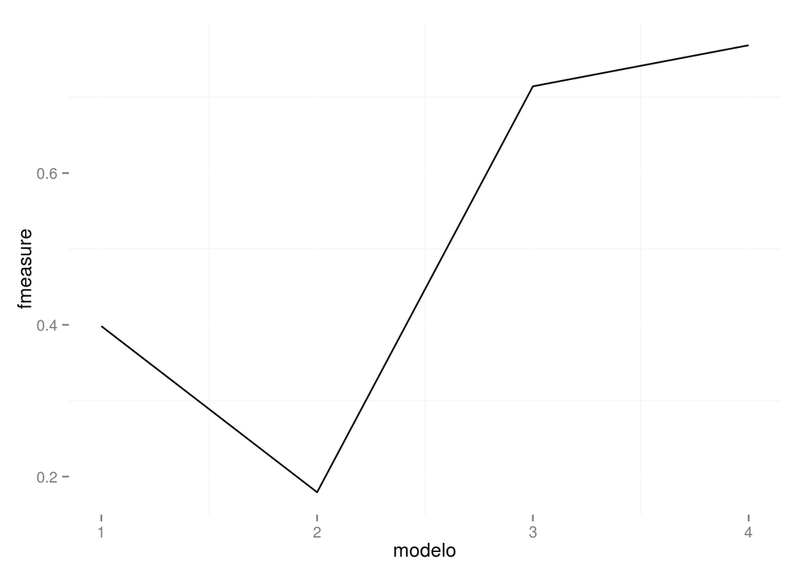

```r
modelo = c(1, 2, 3, 4)
fmeasure = c(fmeasure1, fmeasure2, fmeasure3, fmeasure4)
dataframe = data.frame(fmeasure, modelo)

library(ggplot2)

ggplot(dataframe, aes(modelo, fmeasure) ) + geom_line() + theme(panel.background=element_blank())
```

```r
test_real <- read.csv("~/Projetos/DataAnalysis/Assignment5/test_second_round_kaggle_sem_acento.csv")

#Transformação para factor
test_real$COD_CURSO <- as.factor(test_real$COD_CURSO)
test_real$CODIGO <- as.factor(test_real$CODIGO)
test_real$CREDITOS <- as.factor(test_real$CREDITOS)
test_real$MEDIA[is.na(test_real$MEDIA)] <- -1

media <- summarise(group_by(test_real, MATRICULA), mean(MEDIA))
names(media) <- c("MATRICULA", "MEDIATOTAL")

reprovacao <- summarise(group_by(filter(test_real, SITUACAO=="Reprovado"), MATRICULA), n())
names(reprovacao) <- c("MATRICULA", "REPROVACAO")

aprovado <- summarise(group_by(filter(test_real, SITUACAO=="Aprovado"), MATRICULA), n())
names(aprovado) <- c("MATRICULA", "APROVADO")

target <- c("Reprovado por Falta", NA)
reprovado_falta <- summarise(group_by(filter(test_real, SITUACAO %in% target), MATRICULA), n())
names(reprovado_falta) <- c("MATRICULA", "REPROVADOFALTA")

target <- c("Reprovado por Falta", "Reprovado", "Trancado")
n_aprovado <- summarise(group_by(filter(test_real, SITUACAO %in% target), MATRICULA), n())
names(n_aprovado) <- c("MATRICULA", "NAPROVADO")


#Merge dos novos atributos
test_real <- merge(test_real, media, by = "MATRICULA", all = TRUE)
test_real <- merge(test_real, reprovacao, by = "MATRICULA", all = TRUE)
test_real <- merge(test_real, aprovado, by = "MATRICULA", all = TRUE)
test_real <- merge(test_real, reprovado_falta, by = "MATRICULA", all = TRUE)
test_real <- merge(test_real, n_aprovado, by = "MATRICULA", all = TRUE)

#Transformando NA em 0
test_real[is.na(test_real)] <- 0

pred <- predict(model_florest, test_real[,c(3,5,7,9,10,11,14,15,16,17,18)])
summary(pred)
```

```
##   0   1
## 577   5
```

```r
test_real["COD_EVASAO"] <- pred

write.csv(select(test_real, ID, COD_EVASAO), file="~/Projetos/DataAnalysis/Assignment5/submissao/submissaoRound15.csv", row.names = FALSE)
```

Esse último modelo foi o escolhido para a submissão final no kaggle.